# Chromatography Lab Report

Alvin He  
10/11/2022  
Chemistry Honors 1°

## Results

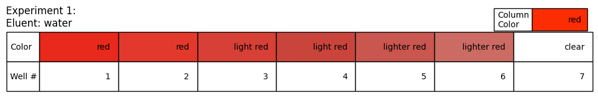

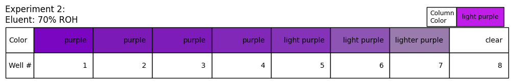

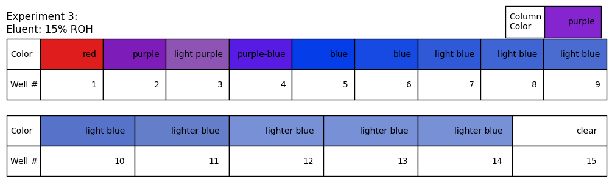

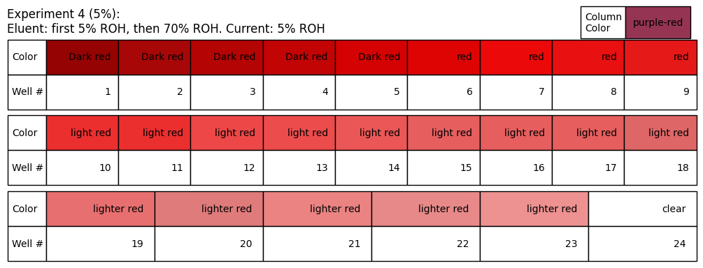

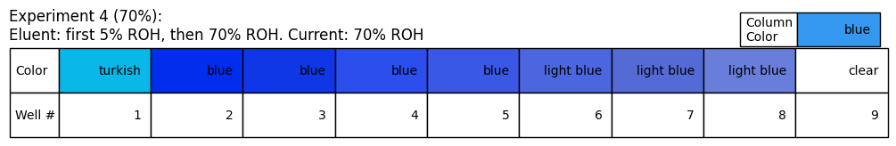

## Discussion

### Experiment 2:

> Both dyes were eluated simulateneously. The mobile phase now contains 70% ROH so it becomes less polar than water. The dyes were both eluated simulateneously means that 70% ROH(isopropyl alcohol - mobile phase) have a similar molecular polarity compared to the dyes, causing both of the dyes to be attracted to it and get eluated.

### Experiment 3:

> The dyes were eluated seperatly. The mobile phase(15% ROH) is more polar compared to 70% ROH, in which the dyes were eluated simulateneously. The dye that's a bit more polar will be eluated first(red dye) and the one that's less polar will be eluated later(blue dye). The red dye and the blue dye both get attracted to the isopropyl alcohol, but since the mobile phase is diluted with water, it's more polar and the more poler red dye gets eluated first. The blue dye was less polar so it took much longer to be eluated compared to the red dye.

### Experiement 4:

> The 5% ROH phase only had the red dye eluated. This is because the red dye probably have similar molecular polarity with the 5% ROH, which is polar. The polarity of the blue dye that wasn't eluated is probably more non-polar, in which is was more attached/attracted to the stationary phase and did not get eluated.

> The 70% ROH phase eluated the rest of the blue dye. This is cause by the blue dye being less polar compared to the red dye so it didn't get carried along in the 5% ROH phase.

#### Note:

- To see more of the code/the ipynb file, please view github: https://github.com/Alvin-He/jupyter-notebooks/blob/main/Chromtography.ipynb